# Toritos

Derek Corcoran

November 22, 2015

# Toritos

Metemos los datos

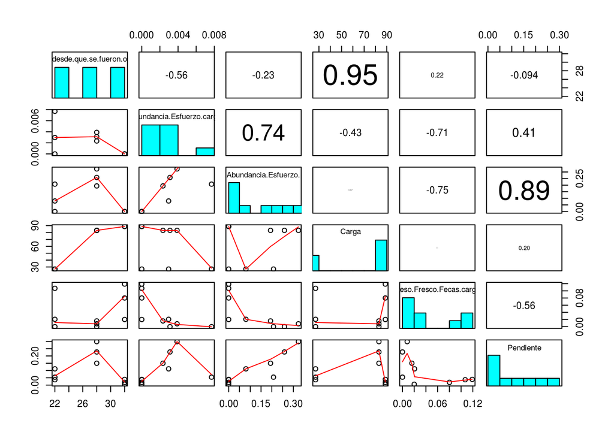

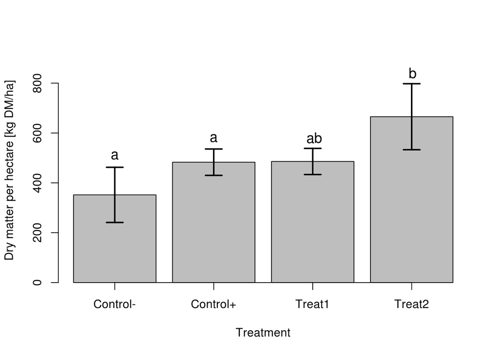

| model | aicc | weights |
| --- | --- | --- |
| Abundancia.Esfuerzo. ~ 1 + Peso.Fresco.Fecas.carga | -8.970360 | 0.2336313 |
| Abundancia.Esfuerzo. ~ 1 + Pendiente + I(Carga^2) | -8.950606 | 0.2313350 |
| Abundancia.Esfuerzo. ~ 1 + Carga + Pendiente | -8.917003 | 0.2274807 |
| Abundancia.Esfuerzo. ~ 1 + Pendiente + I(Pendiente^2) | -8.491436 | 0.1838797 |
| Abundancia.Esfuerzo. ~ 1 + Carga + I(Carga^2) | -7.698159 | 0.1236733 |

| model | aicc | weights |
| --- | --- | --- |
| Abundancia.Esfuerzo.carga. ~ 1 + Peso.Fresco.Fecas.carga | -78.14280 | 0.5255374 |
| Abundancia.Esfuerzo.carga. ~ 1 + I(Peso.Fresco.Fecas.carga^2) | -76.19877 | 0.1988215 |
| Abundancia.Esfuerzo.carga. ~ 1 + I(Dias.desde.que.se.fueron.ovinos^2) | -75.51661 | 0.1413623 |
| Abundancia.Esfuerzo.carga. ~ 1 + Dias.desde.que.se.fueron.ovinos | -75.27928 | 0.1255449 |
| Abundancia.Esfuerzo.carga. ~ 1 + Pendiente + I(Carga^2) | -69.94839 | 0.0087339 |

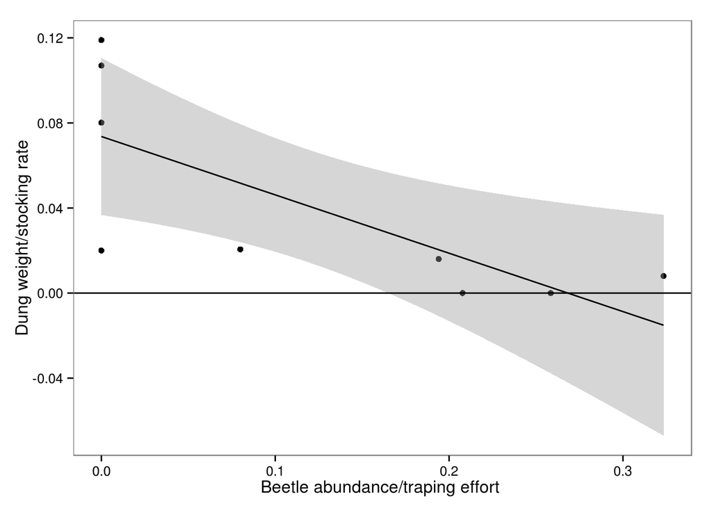

Call: glm(formula = Abundancia.Esfuerzo. ~ 1 + Peso.Fresco.Fecas.carga, data = regresion.toritos)

Deviance Residuals: Min 1Q Median 3Q Max  
-0.16128 -0.03881 0.01591 0.04028 0.13759

Coefficients: Estimate Std. Error t value Pr(>|t|)  
(Intercept) 0.20210 0.04152 4.868 0.00182 ** Peso.Fresco.Fecas.carga -2.03755 0.68388 -2.979 0.02053 * — Signif. codes: 0 ‘**’ 0.001 ’**’ 0.01 ’’ 0.05 ‘.’ 0.1 ‘’ 1

(Dispersion parameter for gaussian family taken to be 0.008368594)

```
Null deviance: 0.13287  on 8  degrees of freedom
```

Residual deviance: 0.05858 on 7 degrees of freedom AIC: -13.77

Number of Fisher Scoring iterations: 2

**Results**

[output not shown]

Call: lm(formula = Abundancia.Esfuerzo. ~ 1 + Peso.Fresco.Fecas.carga, data = regresion.toritos)

Residuals: Min 1Q Median 3Q Max -0.16128 -0.03881 0.01591 0.04028 0.13759

Coefficients: Estimate Std. Error t value Pr(>|t|)  
(Intercept) 0.20210 0.04152 4.868 0.00182 ** Peso.Fresco.Fecas.carga -2.03755 0.68388 -2.979 0.02053 * — Signif. codes: 0 ‘**’ 0.001 ’**’ 0.01 ’’ 0.05 ‘.’ 0.1 ‘’ 1

Residual standard error: 0.09148 on 7 degrees of freedom Multiple R-squared: 0.5591, Adjusted R-squared: 0.4961 F-statistic: 8.877 on 1 and 7 DF, p-value: 0.02053

**Results**

|  | *Dependent variable:* |
| --- | --- |
|  | Abundancia.Esfuerzo. |
| Peso.Fresco.Fecas.carga | -2.038** |
|  | (0.684) |
| Constant | 0.202*** |
|  | (0.042) |
| Observations | 9 |
| R<sup>2</sup> | 0.559 |
| Adjusted R<sup>2</sup> | 0.496 |
| Residual Std. Error | 0.091 (df = 7) |
| F Statistic | 8.877** (df = 1; 7) |
| *Note:* | p<0.1; p<0.05; p<0.01 |

# Results

[output not shown]

[output not shown]

```
## maptype = "toner" is only available with source = "stamen".
## resetting to source = "stamen"...
```

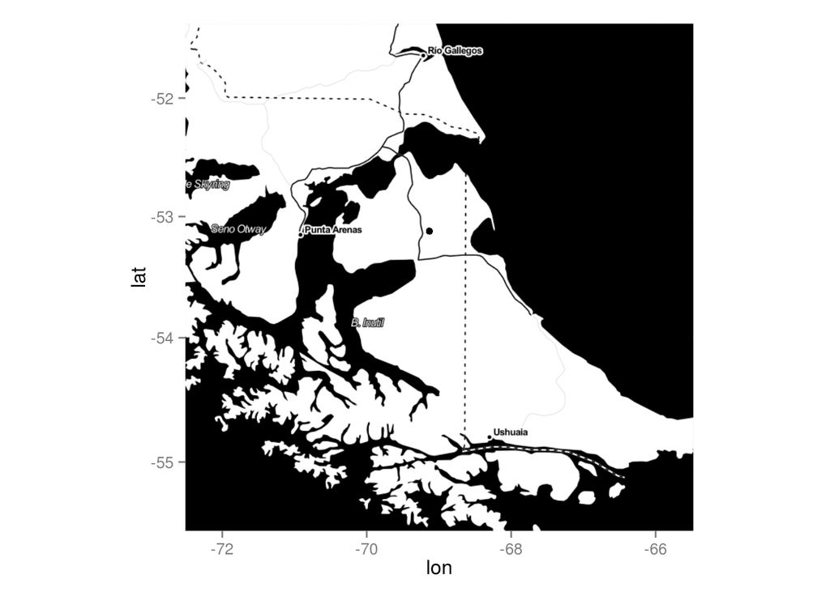

[figure not shown]

```
##             Df Sum Sq Mean Sq F value   Pr(>F)
## Tratamiento  3 248107   82702   9.364 0.000826 ***
## Residuals   16 141307    8832
## ---
## Signif. codes:  0 '***' 0.001 '**' 0.01 '*' 0.05 '.' 0.1 ' ' 1
```

```
##
##  Shapiro-Wilk normality test
##
## data:  exit_bugs$residuals
## W = 0.95431, p-value = 0.4372
```

```
##
##  Bartlett test of homogeneity of variances
##
## data:  Peso.pasto by Tratamiento
## Bartlett's K-squared = 4.7163, df = 3, p-value = 0.1938
```

```
## $statistics
##       Mean      CV MSerror      HSD
##   498.9394 18.8357    8832 170.0515
##
## $parameters
##   Df ntr StudentizedRange alpha  test               name.t
##   16   4         4.046093  0.05 Tukey Toritos3$Tratamiento
##
## $means
##                  Toritos3$Peso.pasto       std r      Min      Max
## Control Negativo            351.7441 110.69710 5 226.7340 496.9697
## Control Positivo            482.8687  52.93513 5 426.9360 553.4680
## Tratamiento 1               495.8114  52.44917 5 451.8519 581.4815
## Tratamiento 2               665.3333 132.36302 5 494.9495 800.1347
##
## $comparison
## NULL
##
## $groups
##                trt    means  M
## 1 Tratamiento 2    665.3333  a
## 2 Tratamiento 1    495.8114 ab
## 3 Control Positivo 482.8687  b
## 4 Control Negativo 351.7441  b
```

| model | aicc | weights |
| --- | --- | --- |
| Abundancia.Esfuerzo. ~ 1 + Pendiente + I(Carga^2) | -8.950606 | 0.2599147 |
| Abundancia.Esfuerzo. ~ 1 + Carga + Pendiente | -8.917003 | 0.2555842 |
| Abundancia.Esfuerzo. ~ 1 + Pendiente + I(Pendiente^2) | -8.491436 | 0.2065966 |
| Abundancia.Esfuerzo. ~ 1 + Carga + Dias.desde.que.se.fueron.ovinos + I(Dias.desde.que.se.fueron.ovinos^2) | -7.698159 | 0.1389522 |
| Abundancia.Esfuerzo. ~ 1 + Carga + I(Carga^2) | -7.698159 | 0.1389522 |

**Results**

[output not shown]

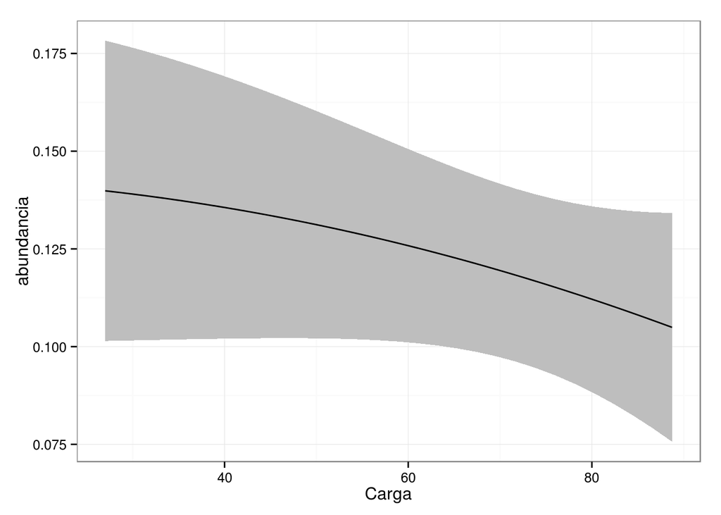

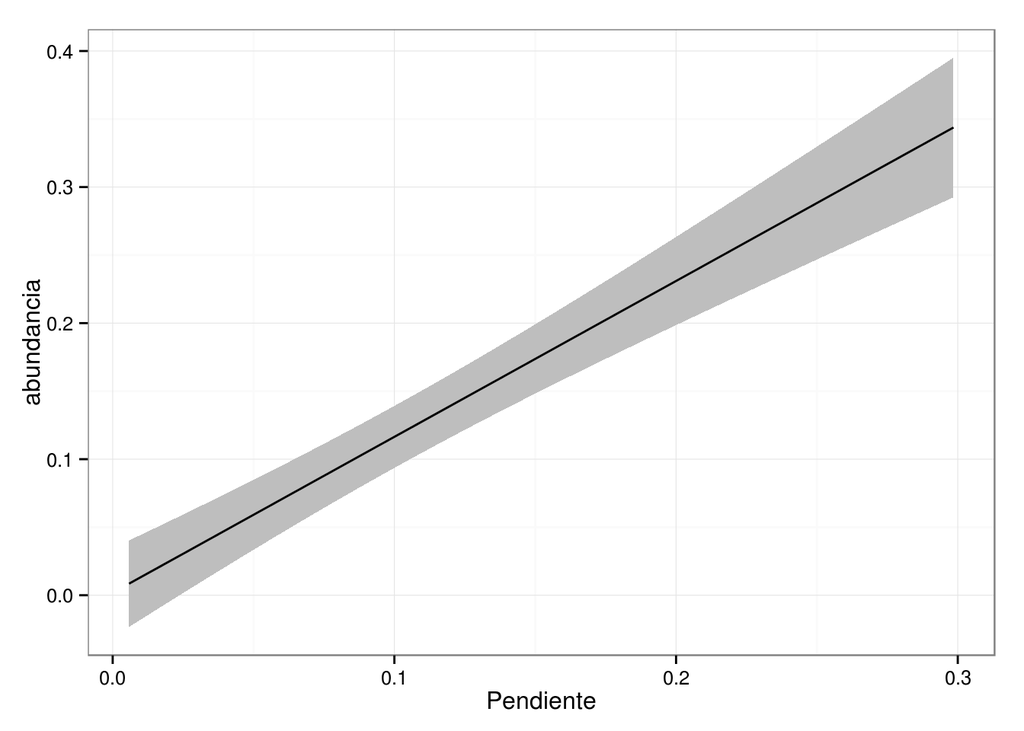

```r
log(regresion.toritos$Abundancia.Esfuerzo.+0.1)
```

```
## [1] -2.3025851 -2.3025851 -2.3025851 -1.2240854 -0.8595768 -1.0259917
## [7] -2.3025851 -1.7153411 -1.1785551
```

```r
Toritos.exp<-lm(log(Abundancia.Esfuerzo.+0.1) ~ 1 + Peso.Fresco.Fecas.carga, data = regresion.toritos)

summary(Toritos.exp)
```

```
##
## Call:
## lm(formula = log(Abundancia.Esfuerzo. + 0.1) ~ 1 + Peso.Fresco.Fecas.carga,
##     data = regresion.toritos)
##
## Residuals:
##      Min       1Q   Median       3Q      Max
## -0.83214 -0.20734  0.08362  0.20492  0.48602
##
## Coefficients:
##                         Estimate Std. Error t value Pr(>|t|)
## (Intercept)              -1.2622     0.1861  -6.781 0.000258 ***
## Peso.Fresco.Fecas.carga -10.3951     3.0659  -3.391 0.011590 *
## ---
## Signif. codes:  0 '***' 0.001 '**' 0.01 '*' 0.05 '.' 0.1 ' ' 1
##
## Residual standard error: 0.4101 on 7 degrees of freedom
## Multiple R-squared:  0.6215, Adjusted R-squared:  0.5675
## F-statistic:  11.5 on 1 and 7 DF,  p-value: 0.01159
```

```r
summary(glm(Abundancia.Esfuerzo. ~ 1 + Peso.Fresco.Fecas.carga, data = regresion.toritos, family = gaussian(link = "log"), start = c(5,0)))
```

```
##
## Call:
## glm(formula = Abundancia.Esfuerzo. ~ 1 + Peso.Fresco.Fecas.carga,
##     family = gaussian(link = "log"), data = regresion.toritos,
##     start = c(5, 0))
##
## Deviance Residuals:
##       Min         1Q     Median         3Q        Max
## -0.113079  -0.030601  -0.007035  -0.001672   0.134728
##
## Coefficients:
##                         Estimate Std. Error t value Pr(>|t|)
## (Intercept)              -1.3262     0.1906  -6.959 0.000219 ***
## Peso.Fresco.Fecas.carga -42.5967    21.1478  -2.014 0.083841 .
## ---
## Signif. codes:  0 '***' 0.001 '**' 0.01 '*' 0.05 '.' 0.1 ' ' 1
##
## (Dispersion parameter for gaussian family taken to be 0.00556321)
##
##     Null deviance: 0.132866  on 8  degrees of freedom
## Residual deviance: 0.038949  on 7  degrees of freedom
## AIC: -17.444
##
## Number of Fisher Scoring iterations: 15
```

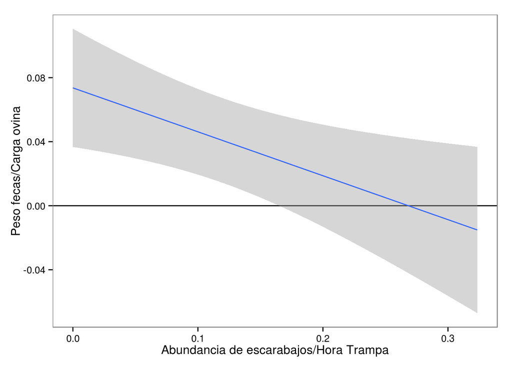

[figure not shown]

```r
#Counts.exponential2 <- exp(predict(Toritos.exp,regresion.toritos$Abundancia.Esfuerzo.))
ggplot(regresion.toritos, aes(Abundancia.Esfuerzo., Peso.Fresco.Fecas.carga))+theme_bw()+labs(x="Abundancia de escarabajos/Hora Trampa", y="Peso fecas/Carga ovina")+ theme(panel.grid.major = element_blank(), panel.grid.minor = element_blank())+ geom_hline(yintercept=0)+geom_smooth(method="lm")
```

```r
Toritos <- read.csv("~/Documents/Toritos1/Toritos/Toritos.csv")
Toritos <- ((Toritos*10000)/(0.34*0.45)/1000)
stargazer(Toritos, type='html', out="hect.html", digits = 2)
```

| Statistic | N | Mean | St. Dev. | Min | Max |
| --- | --- | --- | --- | --- | --- |
| Control.negativo | 5 | 341.40 | 107.44 | 220.07 | 482.35 |
| Control.positivo | 5 | 468.67 | 51.38 | 414.38 | 537.19 |
| Tratamiento.1 | 5 | 481.23 | 50.91 | 438.56 | 564.38 |
| Tratamiento.2 | 5 | 645.76 | 128.47 | 480.39 | 776.60 |